# Cellular deconvolution with DeCovarT

A network-centric view of bulk mixtures

Bastien Chassagnol

MMG / LPSM / INSERM

Gregory Nuel

Etienne Becht

Anaïs Baudot

2026-10-30

Cellular deconvolution

DeCovarT: a network-centric approach to bulk mixtures

Bastien Chassagnol  
*MMG*

Gregory Nuel  
*LPSM*

Etienne Becht  
*INSERM*

Anaïs Baudot  
*MMG*

Slides: [GitHub](https://github.com/bastienchassagnol/DeCovarT/tree/main/slides) · Full screen after render: `slides/index.html`

## Outline

1. Why deconvolution?
2. A review of deconvolution techniques
3. DeCovarT: a network-centric approach
4. Biological applications and perspectives
5. Quiz

# Why deconvolution?

## Quantify components of biological systems

Bulk tissues mix cell populations. Autoimmunity and cancer change both **composition** and **state** of those populations (Schnell et al. 2020).

[figure not shown]

Figure 1: Immune balance as a seesaw between regulation and inflammation.

Schnell et al. (2020)

## Immune balance (schematic)

Complementary schematic of Figure 1:

[output not shown]

Figure 2: Healthy balance vs under- and over-reaction.

Schnell et al. (2020)

## Holistic complexity

Genes cooperate in pathways; metabolites and cell populations interact in bio-molecular networks. Deconvolution alone is not enough — we need **structure** on the gene side as well (Schnell et al. 2020).

[figure not shown]

Figure 3: Holistic view: transcriptome and cell populations feed immune balance.

Schnell et al. (2020)

## Why bulk is limited for biomarkers

Shoemaker et al. (2012): the same bulk fold-change can come from

- **Scenario A** — activation within an existing cell type
- **Scenario B** — arrival of a new cell population (Figure 5)

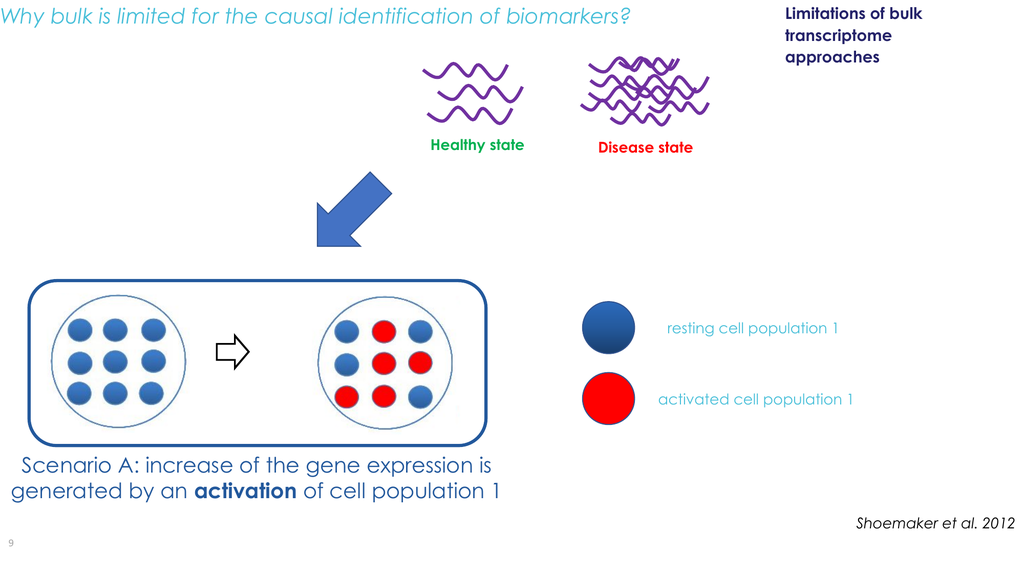

Figure 4: Scenario A: within-type activation.

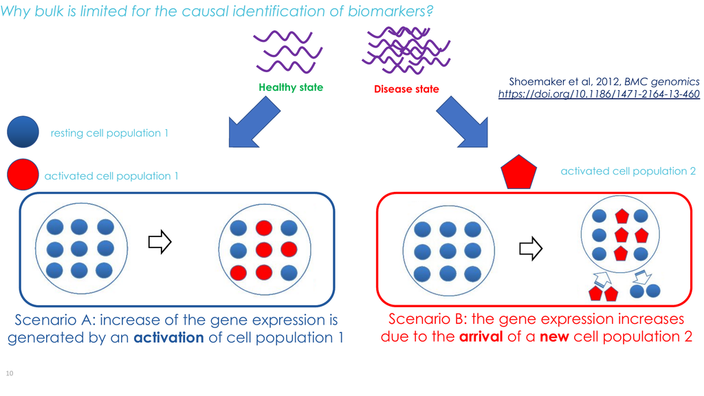

Figure 5: Scenario B: new population.

Shoemaker et al. (2012)

## Technical alternatives

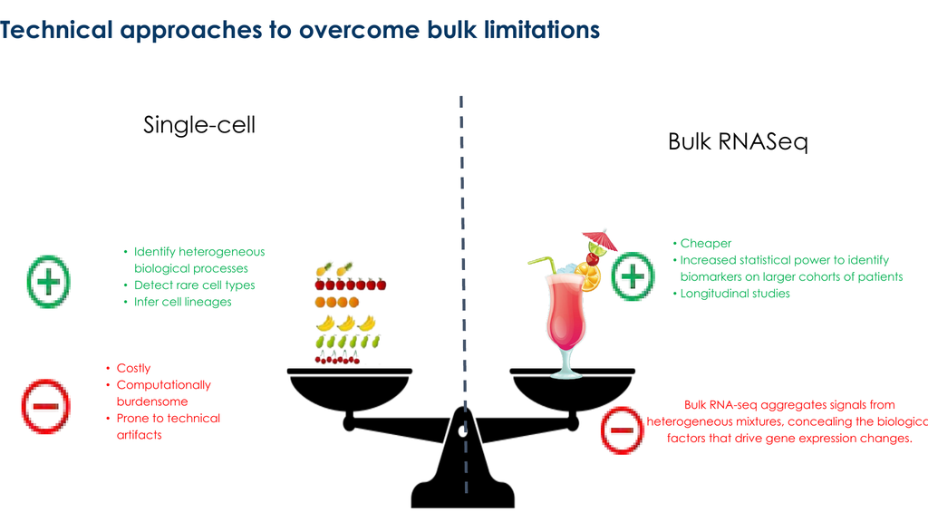

Figure 6: Bulk versus single-cell trade-offs.

**Bulk RNA-seq**

- Cheaper, larger cohorts
- Longitudinal studies
- Aggregates heterogeneous signals

**Single-cell / spatial**

- Resolve rare types & lineages
- Costly, noisy, heavy compute
- Complements bulk rather than replaces it

Deconvolution recovers cell-type proportions from bulk when single-cell is impractical at scale.

# Review of techniques

## The ecosystem of algorithms

Taxonomy after Shen-Orr & Gannett (2013) and reviews such as Avila Cobos et al. (2018), Gaspard-Boulinc et al. (2025):

- **Partial deconvolution** — estimate proportions $p$ given signature $X$
- **Complete deconvolution** — jointly infer $p$ and $X$ (ill-posed without priors)

## Granularity

Deconvolution targets vary:

- Mixtures of **cell populations** (e.g. immune fractions)
- Mixtures of **tissues** (e.g. tumour purity)
- Mixtures of **cell-cycle phases**

## Reference-based principle

[figure not shown]

Figure 7: Signature $X$, bulk $y$, proportions $p$.

1. Purified cellular profiles (signature matrix $X$)
2. Bulk mixture $y$
3. Estimate proportions $p$ (often with simplex constraints)

Classic tools include DeconRNASeq (Gong and Szustakowski 2013), CIBERSORT (Newman et al. 2015), and EPIC (Racle et al. 2017).

Avila Cobos et al. (2018)

## Signature-based families

Compact survey of common reference-based tools (Table 1):

Table 1: Selected reference-based deconvolution methods.

| Method | Family | Citation |
| --- | --- | --- |
| DeconRNASeq | QP / least squares | Gong & Szustakowski, 2013 |
| CIBERSORT | SVR (robust) | Newman et al., 2015 |
| EPIC | Weighted QP | Racle et al., 2017 |
| quanTIseq | Weighted QP | Finotello et al., 2018 |
| FARDEEP | Robust regression | Hao et al., 2019 |

**Regression**

- Quadratic programming (DeconRNASeq)
- Robust / SVR (CIBERSORT, FARDEEP)
- Weighted QP (EPIC, quanTIseq)

**Probabilistic**

- Continuous: DSection, DeMix
- Discrete: PERT, TEMT

# DeCovarT

## Global pipeline

[figure not shown]

Figure 8: From references to biological exploitation.

1. Collect / curate cell-type datasets
2. Learn features & GRN structure
3. **DeCovarT** estimation of $p$
4. Biological exploitation

Avila Cobos et al. (2018)

## Multivariate Gaussian convolution

Cell type $j$: $x_j \sim \mathcal{N}_G(\mu_j, \Sigma_j)$.

Bulk observation (Equation 1):

$$y \mid p \;\sim\;
\mathcal{N}_G\!\Bigl(
\mu p,\;
\sum_j p_j^{2}\,\Sigma_j
\Bigr).
\tag{1}$$

- $G$: number of genes (dimension of $y$)
- $J$: number of cell types; $p \in \Delta^{J-1}$
- $\mu$: $G \times J$ mean signature; $\Sigma_j$: gene–gene covariance of type $j$

Covariance structure enters the likelihood — gene–gene dependence is first-class, not noise.

[figure not shown]

Figure 9: Another view of the convolution principle.

## Unit-simplex constraint

Proportions live on $\Delta^{J-1}$. DeCovarT uses an unconstrained map $\rho \mapsto p$ (additive logistic / soft-max) that is a $C^{2}$-diffeomorphism, then optimises with Marquardt–Levenberg.

## Toy model (2 cells × 2 genes)

Bivariate convolutions make the geometry visible: entropy of $p$, overlap of $\Sigma_j$, and solver behaviour (DeconRNASeq vs DeCovarT). See Figure 10 and Figure 11.

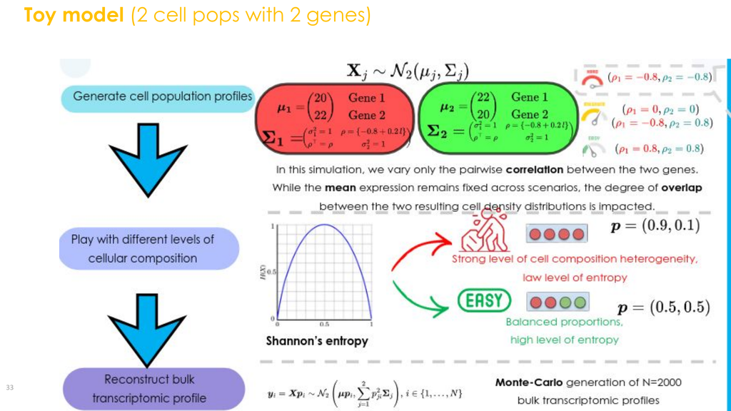

Figure 10: Toy bivariate setup.

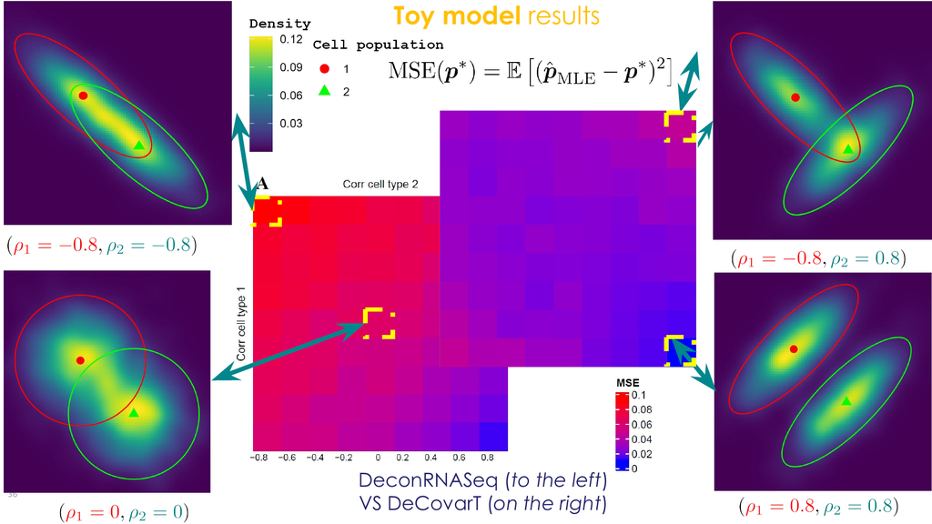

Figure 11: Toy estimation results.

Package vignettes: synthetic scenarios and [`run_simulation_benchmark()`](https://bastienchassagnol.github.io/DeCovarT/reference/run_simulation_benchmark.html) with scenario grids from `scripts/fig02_bivariate_toy.R`.

# Applications & perspectives

## Sjögren’s disease

Transcriptomic patient clusters and IFN modules motivate composition-aware analysis of immune infiltration (Soret et al. 2021).

[figure not shown]

Figure 12: Sjögren patient stratification motivating deconvolution.

Soret et al. (2021)

## DTOO / gastruloid perspectives

Digital twins and multimodal gastruloid maps need deconvolution across bulk, single-cell, and ATAC layers — composition + covariance again.

## Spatial deconvolution (outlook)

Emerging toolkits mix (Gaspard-Boulinc et al. 2025):

- Graph / optimal transport pairing of cells to spots
- Bayesian count models (NB, Poisson–gamma, topic models)
- Regression with simplex / robust / ensemble constraints

Gaspard-Boulinc et al. (2025)

## Perspectives for DeCovarT

- Rare / unknown cell content and spillover
- Multi-omics and spatio-temporal resolution
- Hierarchical ontologies (coarse vs fine labels)
- Compositional statistics on $p$

# Quiz

## What does reference-based deconvolution estimate?

- Gene regulatory network topology only
- Cell-type proportions $p$ given a signature $X$
- Single-cell UMAP embeddings
- Batch-correction factors alone

## Which statement about DeCovarT is true?

- It ignores gene–gene covariance
- It models bulk as a Gaussian convolution with covariance $\sum_j p_j^2\Sigma_j$
- It only works on DNA methylation
- It requires spatial coordinates for every cell

## Scenario A vs B (Shoemaker 2012)

A bulk gene increases. Scenario B means:

- The same cell type up-regulates the gene
- A new cell population arrives in the mixture
- Sequencing depth doubled
- The gene was a spike-in control

# Acknowledgements

## Thanks

**Supervision & co-authors**

- Anaïs Baudot
- Gregory Nuel
- Etienne Becht
- Marielle Péré

**Collaborators**

- SysBioMed / MMG colleagues
- Doctorants seminar organisers

## References

Avila Cobos, Francisco, Jo Vandesompele, Pieter Mestdagh, and Katleen De Preter. 2018. ‘Computational Deconvolution of Transcriptomics Data from Mixed Cell Populations’. *Bioinformatics (Oxford, England)* 34. https://doi.org/10.1093/bioinformatics/bty019.

Gaspard-Boulinc, Lucie C., Luca Gortana, Thomas Walter, Emmanuel Barillot, and Florence M. G. Cavalli. 2025. ‘Cell-Type Deconvolution Methods for Spatial Transcriptomics’. *Nature Reviews Genetics* 26. https://doi.org/10.1038/s41576-025-00845-y.

Gong, Ting, and Joseph D. Szustakowski. 2013. ‘DeconRNASeq: A Statistical Framework for Deconvolution of Heterogeneous Tissue Samples Based on mRNA-Seq Data’. *Bioinformatics (Oxford, England)* 29. https://doi.org/10.1093/bioinformatics/btt090.

Newman, Aaron, Chih Liu, Michael Green, et al. 2015. ‘Robust Enumeration of Cell Subsets from Tissue Expression Profiles’. *Nature Methods* 12. https://doi.org/10.1038/nmeth.3337.

Racle, Julien, Kaat de Jonge, Petra Baumgaertner, Daniel E Speiser, and David Gfeller. 2017. ‘Simultaneous Enumeration of Cancer and Immune Cell Types from Bulk Tumor Gene Expression Data’. *eLife* 6. https://doi.org/10.7554/elife.26476.

Schnell, Alexandra, Lloyd Bod, Asaf Madi, and Vijay K. Kuchroo. 2020. ‘The Yin and Yang of Co-Inhibitory Receptors: Toward Anti-Tumor Immunity Without Autoimmunity’. *Cell Research* 30. https://doi.org/10.1038/s41422-020-0277-x.

Shoemaker, Jason E., Tiago JS Lopes, Samik Ghosh, Yukiko Matsuoka, Yoshihiro Kawaoka, and Hiroaki Kitano. 2012. ‘CTen: A Web-Based Platform for Identifying Enriched Cell Types from Heterogeneous Microarray Data’. *BMC Genomics* 13. https://doi.org/10.1186/1471-2164-13-460.

Soret, Perrine, Christelle Le Dantec, Emiko Desvaux, et al. 2021. ‘A New Molecular Classification to Drive Precision Treatment Strategies in Primary Sjögren’s Syndrome’. *Nature Communications* 12. https://doi.org/10.1038/s41467-021-23949-4.